## NOAA Severe Weather Events Analysis 1950 to 2011

Author: David Severson  
Date: May 22, 2015

### 1.0 Synopsis

Weather events can have a considerable impact on people and damage to property. In this analysis the NOAA Storm Database has been used to provide policy makers a better understanding of these impacts. An analysis of impacts to people is provided by a total picture of fatalities and injuries. An analysis of weather events cost are provided by the total dollar impacts to property and crops. The events with the largest impacts are shown in both catagories.

The results clearly indicate that tornados cause the greatest numbers of fatalities and injuries. All other events indicate a rapidly deminishing impact to the population.

The cost of damages to property and crops is largely caused by flooding of various types.

### 2.0 Data Processing

All data for this analysis comes from the [NOAA Storm Database](https://d396qusza40orc.cloudfront.net/repdata%2Fdata%2FStormData.csv.bz2). There is a [Storm Data Documentation](https://d396qusza40orc.cloudfront.net/repdata%2Fpeer2_doc%2Fpd01016005curr.pdf) manual available for review along with an [FAQ](https://d396qusza40orc.cloudfront.net/repdata%2Fpeer2_doc%2FNCDC%20Storm%20Events-FAQ%20Page.pdf).

#### 2.1 Setup Libraries and Validating Environment

```r
library(ggplot2)
```

#### 2.2 Loading Data

We use an R function for decompressing the bz2 file and read the data into an R dataframe with the read.csv function as normal.

```r
filename<-"repdata_data_StormData.csv.bz2"
storm<-read.csv(bzfile(filename))
```

#### 2.3 User Functions

We have one key function that is used to remove space before and after the EVTYPE field in the data. The function is credited to a stackexchange.com contributor.

```r
trim <- function (x) gsub("^\\s+|\\s+$", "", x)
```

#### 2.4 Population Impact Data Preparation

For this analysis the total number of fatalities and injuries were combined for each event. This approach was used to provide the clearest understanding of human impact by these weather events. This impact was stored in a new variable for use in the analysis.

```r
storm$humanimpact<-storm$FATALITIES+storm$INJURIES
```

#### 2.5 Property and Crop Impact Data Preparation

Two fields of the data indicated the scale of the cost estimate. PROPDMGEXP and CROPDMGEXP, the “EXP” fields, may indicate K, M or B which respectively indicate the cost estimates were in the thousands, millions or billions. For this preparation we setup a factor that will be multiplied by the estimate. We set this factor to 1 by default. If the “EXP” fields incidate K, M Or B we substitute the appropriate factor. All other values for the “EXP” fields did not have an impact on the approach to this analysis.

```r
storm$propfactor<-1 # setting a default value of 1 for multiplication
storm$propfactor[storm$PROPDMGEXP=="K"]<-1000       # one thousand
storm$propfactor[storm$PROPDMGEXP=="M"]<-1000000    # one million
storm$propfactor[storm$PROPDMGEXP=="B"]<-1000000000 # one billion
storm$cropfactor<-1 # setting a default of 1
storm$cropfactor[storm$CROPDMGEXP=="K"]<-1000       # thousand
storm$cropfactor[storm$CROPDMGEXP=="M"]<-1000000    # million
storm$cropfactor[storm$CROPDMGEXP=="B"]<-1000000000 # billion

# the cost estimates for both property and crop are multiplied by the factor
# and totaled to one number
costimpact<-storm$PROPDMG*storm$propfactor + storm$CROPDMG*storm$cropfactor
```

#### 2.6 Event Type Data Preparation

There are over 900 unique event types in the raw data. To provide the clearest picture of weather impact the following list shows the key data transformations that were used to provide the clearest understanding of weather impact.

- all weather event names were convereted to upper case to increase matching and grouping
- spaces were removed from the beginning and end of all event strings
- weather events that generally had the same characteristics and impact were grouped together
- grouped events were:
- events related to heat or hot weather
- events related to wind or windy conditions
- events related to floods or flooding
- events related to winter, blizzard or snow related events

Finally all the impacts to people and costs were summarized into two new dataframes.

```r
storm$eventtype<-toupper(trim(storm$EVTYPE))
storm$eventtype[grep("HEAT",storm$eventtype)]<-"HOT WEATHER EVENT*"
storm$eventtype[grep("WIND",storm$eventtype)]<-"WINDY WEATHER EVENT*"
storm$eventtype[grep("FLOOD",storm$eventtype)]<-"FLOOD EVENT*"
storm$eventtype[grep("WINTER",storm$eventtype)]<-"WINTER EVENT*"
storm$eventtype[grep("BLIZZARD",storm$eventtype)]<-"WINTER EVENT*"
storm$eventtype[grep("SNOW",storm$eventtype)]<-"WINTER EVENT*"
storm$eventtype[grep("RIP CURRENT",storm$eventtype)]<-"RIP CURRENT"

humanimpact.df<-aggregate(humanimpact ~ eventtype, data=storm, sum)

costimpact.df<-aggregate(costimpact ~ eventtype, data=storm, sum)
```

### 3.0 Results

#### 3.1 Severe Weather Impact to People

For these results the 15 weather events with the most combined fatalities and injuries were selected and plotted. Tornados clearly cause the largest impact based on fatalities and injuries.

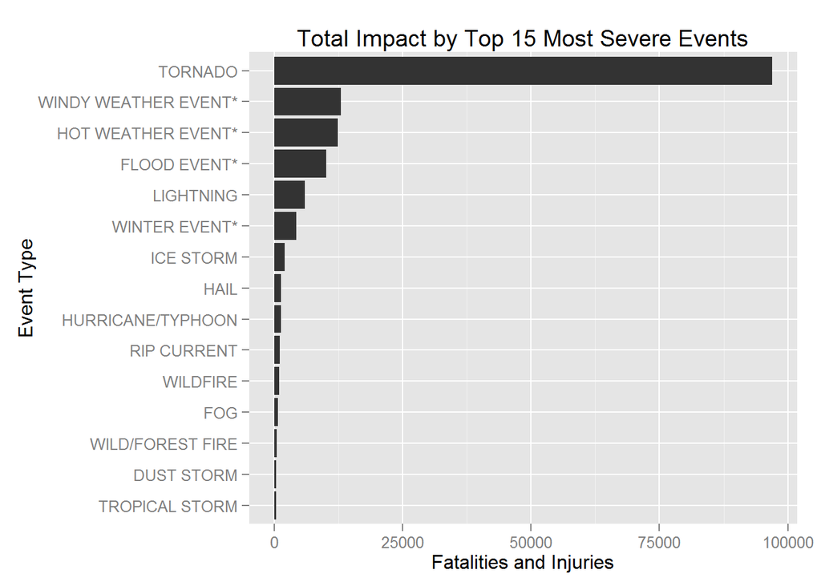

```r
plotdata<-tail(humanimpact.df[order(humanimpact.df$humanimpact),],15)
# next, factor variables are reorder to put largest bar on top
plotdata$eventtype <- reorder(plotdata$eventtype, plotdata$humanimpact)

plot<-ggplot(plotdata,aes(x=factor(eventtype),y=humanimpact)) +
stat_summary(fun.y=mean,geom="bar") + coord_flip() +
xlab("Event Type") + ylab("Fatalities and Injuries") +
ggtitle("Total Impact by Top 15 Most Severe Events")

print(plot)
```

#### 3.2 Severe Weather Impact to Property and Crops

For these results the 15 weather events with the most total damages were selected and plotted. Various types of flood events cause the largest cost impacts.

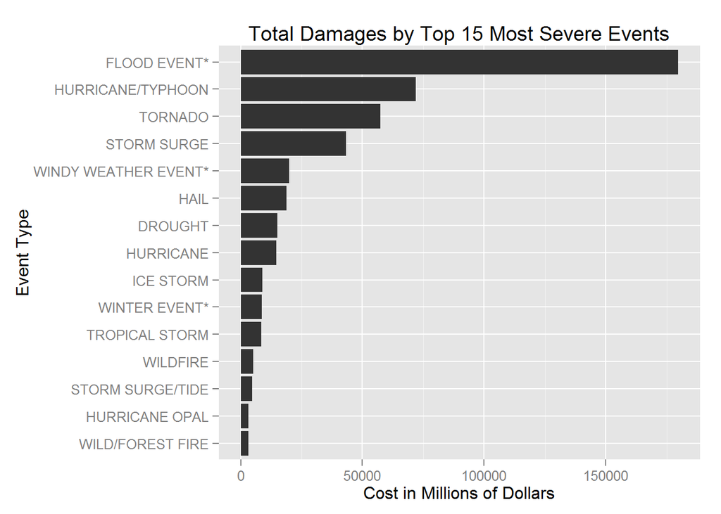

```r
plotdata<-tail(costimpact.df[order(costimpact.df$costimpact),],15)
# next, factor variables are reorder to put largest bar on top
plotdata$eventtype <- reorder(plotdata$eventtype, plotdata$costimpact)

plot<-ggplot(plotdata,aes(x=factor(eventtype),y=costimpact/1000000)) + stat_summary(fun.y=mean,geom="bar") + coord_flip() +
xlab("Event Type") + ylab("Cost in Millions of Dollars") +
ggtitle("Total Damages by Top 15 Most Severe Events")

print(plot)
```